# HW2 Optimization

Jing Li

October 21, 2017

## 2.1 Matrix Representation

Using R, we can generate a random n×n adjacency matrix as follows. In the example below, each edge has a 20% chance of occuring.

```r
n <- 50
d <- runif(n*n)
d[d < 0.8] <- NA
d <- matrix(d, nrow = n, ncol = n)
diag(d) <- NA
d[upper.tri(d)] = t(d)[upper.tri(d)]
```

## 2.2 Adjacency Matrix to Adjacency List

Write a function to convert adjacency matrix to an adjcency list called ds

```r
AdjMatrix2List <- function(d){
  ds <- matrix(ncol = 3,dimnames = list(NULL,c("head","tail","weight")))
  for (i in 1:nrow(d)){
    for (j in 1:nrow(d)){
      if(!is.na(d[i,j])){
        ds <- rbind(ds,c(i,j,d[i,j]))
      }
    }
  }
  ds <- ds[-1,]
  return(ds)
}
head(AdjMatrix2List(d),50)
```

```
##       head tail    weight
##  [1,]    1    6 0.9882457
##  [2,]    1    9 0.8521859
##  [3,]    1   11 0.8377142
##  [4,]    1   35 0.9287801
##  [5,]    1   36 0.8485544
##  [6,]    1   40 0.8828462
##  [7,]    1   42 0.8901144
##  [8,]    1   47 0.9422312
##  [9,]    1   49 0.8268700
## [10,]    2    4 0.8109515
## [11,]    2   12 0.8567695
## [12,]    2   13 0.9682856
## [13,]    2   16 0.9402699
## [14,]    2   17 0.8534715
```

[output cut: 36 more lines]

## 3 Euclidean Minimum Spanning Tree

Create a euclidean minimum tree on a set of random (x,y) coordinates. We want to build and visualize a network that connects all of the coordinates at minimum cost we can generate a random set of 50 coordinates

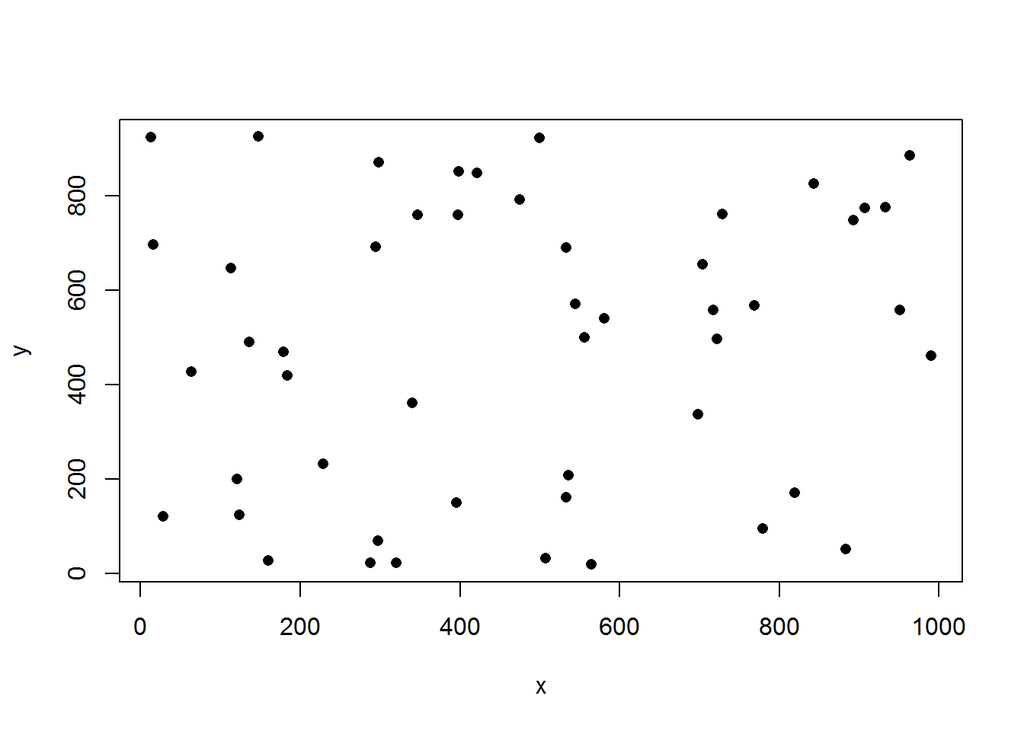

```r
n <- 50
x <- round(runif(n)*1000)
y <- round(runif(n)*1000)
plot(x,y,pch=16)
```

## 3.1 Adjacency Matrix

Create an adjacency matrix d by calculating the euclidean distance between every pair of points

```r
eudist <- function(x,y){
  distance <- c()
  for (i in 1:n){
    for(j in 1:n){
      distance <- c(distance, sqrt((x[j]-x[i])^2+(y[j]-y[i])^2))
    }
  }
  distance <- matrix(distance, nrow = n, ncol = n)
  return(distance)
}

d <- eudist(x,y)
head(d,10)
```

```
##            [,1]      [,2]      [,3]      [,4]      [,5]      [,6]
##  [1,]    0.0000  842.9496  376.4797 219.27608 1019.6568  861.2462
##  [2,]  842.9496    0.0000  723.3982 974.76664  906.4966   81.8352
##  [3,]  376.4797  723.3982    0.0000 595.75582 1232.4889  775.0329
##  [4,]  219.2761  974.7666  595.7558   0.00000  943.9460  976.9550
##  [5,] 1019.6568  906.4966 1232.4889 943.94597    0.0000  835.8834
##  [6,]  861.2462   81.8352  775.0329 976.95496  835.8834    0.0000
##  [7,]  213.2346  932.2687  586.2764  48.83646  900.9334  932.5513
##  [8,]  368.9580  701.4685  625.2591 343.95349  651.0745  684.3281
##  [9,]  393.8947 1017.6389  762.5025 193.66208  807.6639 1004.1723
## [10,]  730.3841  804.0927  973.7125 650.00077  294.4979  751.3880
##            [,7]     [,8]      [,9]    [,10]     [,11]    [,12]    [,13]
##  [1,] 213.23461 368.9580  393.8947 730.3841  347.0519 131.5941 589.4107
##  [2,] 932.26874 701.4685 1017.6389 804.0927 1057.1249 718.0843 821.6429
##  [3,] 586.27639 625.2591  762.5025 973.7125  723.4321 366.8787 866.4468
```

[output cut: 73 more lines]

## 3.2 Adjacency List

Create an adjacency list from the distance adjacency matrix

```r
ds <- AdjMatrix2List(d)
head(ds,50)
```

```
##       head tail     weight
##  [1,]    1    1    0.00000
##  [2,]    1    2  842.94958
##  [3,]    1    3  376.47975
##  [4,]    1    4  219.27608
##  [5,]    1    5 1019.65681
##  [6,]    1    6  861.24619
##  [7,]    1    7  213.23461
##  [8,]    1    8  368.95799
##  [9,]    1    9  393.89466
## [10,]    1   10  730.38415
## [11,]    1   11  347.05187
## [12,]    1   12  131.59407
## [13,]    1   13  589.41072
## [14,]    1   14  692.26079
```

[output cut: 36 more lines]

## 3.3 Calculate the Minimum Spanning Tree using Kruskal or Prim

```r
require(optrees)
ds.mst <- msTreePrim(1:n, ds)
str(ds.mst)
```

```
## List of 4
##  $ tree.nodes : num [1:50] 1 15 12 28 38 7 4 27 11 9 ...
##  $ tree.arcs  : num [1:49, 1:3] 1 1 12 12 38 7 4 4 11 9 ...
##   ..- attr(*, "dimnames")=List of 2
##   .. ..$ : NULL
##   .. ..$ : chr [1:3] "ept1" "ept2" "weight"
##  $ stages     : num 49
##  $ stages.arcs: num [1:49] 1 2 3 4 5 6 7 8 9 10 ...
```

## 3.4 Produce a Plot Visulizing the Minimum Spanning Tree

Using the segments function, draw straight line segments on the plot (x,y) corresponding to the edge in the minimum spanning tree. ept1 is the source code and ept2 is the destination node. ignore the weights

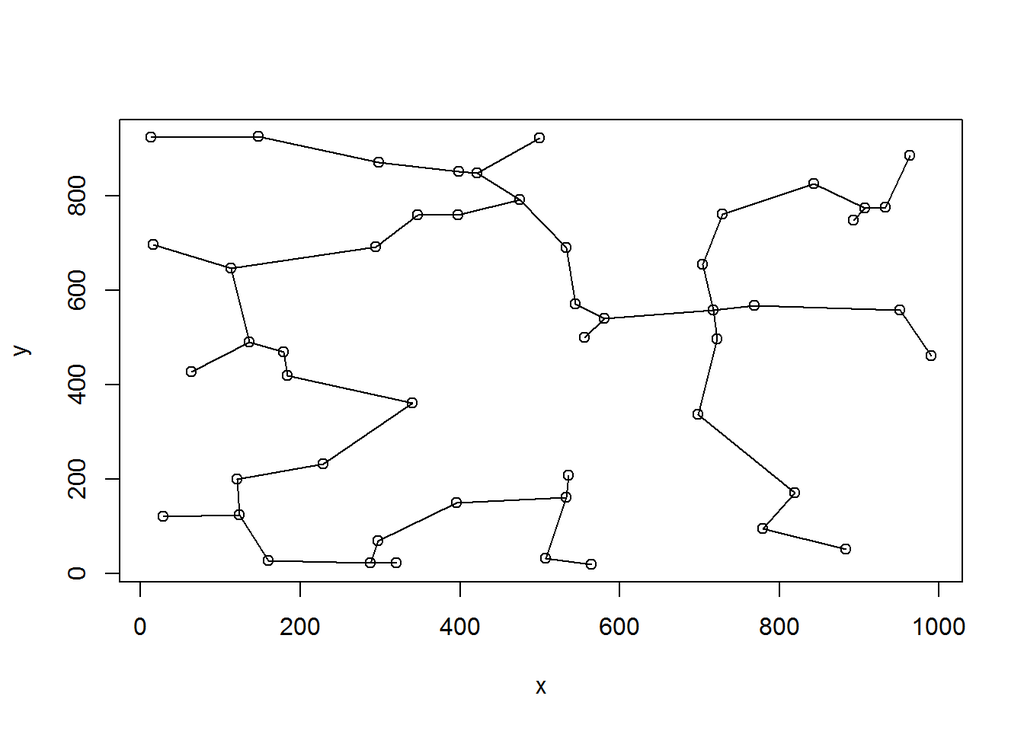

```r
plot(x,y)
xstart <- c()
ystart <- c()
xend <- c()
yend <- c()

plot.mst <- function(ds.mst){
  for(i in 1:nrow(ds.mst$tree.arcs)){
    xstart[i] <- x[ds.mst$tree.arcs[i,][1]]
    ystart[i] <- y[ds.mst$tree.arcs[i,][1]]
    xend[i] <- x[ds.mst$tree.arcs[i,][2]]
    yend[i] <- y[ds.mst$tree.arcs[i,][2]]
  }
  return(segments(xstart,ystart,xend,yend))
}
plot.mst(ds.mst)
```

## 4 Hostile Agents

An intelligence service has n agents in a non-friendly country. Each agent knows some of the other agents and has in place procedures for arranging a rendezvous with anyone he or she knows. For each such possible rendezvous, say between agents i and j, any message passed between these agents will fall into hostile hands with a certain probability pij. The government wants to transmit a confidential message among all the agents while maximizing the total probability that no message is intercepted

## 4.1 Specify This Problem As a Graph Optimization Problem

There are n nodes in a graph. Each nodes has some edges connecting to other nodes. The weight for each edges is a random number between 0 and 1. The task is to specify a starting node then construct a minimum spanning tree that connect all nodes at a minimum cost (overall probability of the intelligence being captured by enemy is minimized)

## 4.2 Structure Inputs to This Problem

We need to initialize a partition structure which has two sets, “key” and “pred” For each vertex v from V, set key[v] = infinity and set pred[v] = -1. We also want to specify key[0] = 0 which indicates our starting node. We then write a priority queue PQ.

The essential “inputs” in this algorithm are E which represents vectors containing all edges and V which represents vectors containing all vertex.

## 4.3 Which Algorithm to Use

The Kruskal algorithm is preferred. Although, both the Prim algorithm and the Kruskal algorithm will construct a minimum spanning tree; and, both algorithms will capture the same of amount of information about the edges (in our case are the individual probabilities that enemy will capture the intelligence) However since we are dealing with probabilities, we would want to multiply probabilities along each edge in order to deliver the intelligence from a starting node to a ending node.

Think this as partitioning sets. There are more intermediate parent nodes between a root node and a individual node in a minimum spanning tree that is produced by the Kruskal algorithm than one produced by the Prim algorithm.

## 5 Project Scheduling

Consider a task A which must be completed before some task B. We can represent all such tasks in a directed acyclic graph (DAG), such that if A happens before B, we include a directed edge from A to B.

## 5.1 Matrix Representation

Represent this scheduling network in R. Associate a completion time with each node.

```r
adj_matrix1 <- matrix(NA,nrow = 10,ncol = 10,dimnames = list(c('A','B','C','D','E','F','G','H','I','J'),c('A','B','C','D','E','F','G',
                                                                                                          'H','I','J')))
adj_matrix1[1,2] <- 90
adj_matrix1[1,6] <- 90
adj_matrix1[1,9] <- 90
adj_matrix1[2,3] <- 15
adj_matrix1[3,7] <- 5
adj_matrix1[4,5] <- 20
adj_matrix1[4,8] <- 20
adj_matrix1[4,10] <- 20
adj_matrix1[6,7] <- 25
adj_matrix1[7,4] <- 14
adj_matrix1[9,10] <- 30
adj_matrix1
```

```
##    A  B  C  D  E  F  G  H  I  J
## A NA 90 NA NA NA 90 NA NA 90 NA
## B NA NA 15 NA NA NA NA NA NA NA
## C NA NA NA NA NA NA  5 NA NA NA
## D NA NA NA NA 20 NA NA 20 NA 20
## E NA NA NA NA NA NA NA NA NA NA
## F NA NA NA NA NA NA 25 NA NA NA
## G NA NA NA 14 NA NA NA NA NA NA
## H NA NA NA NA NA NA NA NA NA NA
## I NA NA NA NA NA NA NA NA NA 30
## J NA NA NA NA NA NA NA NA NA NA
```

## 5.2 Enter, the Management

1. The earliest completion date for the project if it commences on Nov 1, 2017.
2. The earliest and latest start times for each task which will not alter the completion date.
3. The earliest and latest ﬁnish times for each activity that will not alter the completion date.
4. The list of tasks which must adhere to a rigid schedule so as not to delay the overall project, as well as a list of those tasks which have more ﬂexibility.

## 5.4 Earliest Start Times (ES)

To calculate the earliest start times for each node, you will need to solve the longest path problem, starting at source node A, with negative edge weights. The distances output from the algorithm are your earliest start times.

```r
require(optrees)
adj_matrix1 <- adj_matrix1 * -1
adj_list1 <- AdjMatrix2List(adj_matrix1)
ES <- spTreeBellmanFord(1:10, adj_list1,source.node = 1, directed = T)$distances*-1
ES
```

```
##  [1]   0  90 105 129 149  90 115 149  90 149
```

## 5.6 Earliest Finish Times

EF = ES + node duration

```r
s.nodes <- c(90,15,5,20,21,25,14,28,30,45)
EF <- ES + s.nodes
EF
```

```
##  [1]  90 105 110 149 170 115 129 177 120 194
```

## 5.7 Latest Finish Time

The latest ﬁnish times are computed on the transpose of the graph. That is, for each edge from A to B, we reverse its direction and instead have an edge from B to A. we will have to rebuild your edge weights. We are still looking for ﬁnish times along the (longest) critical path, so again, we ﬂip the edge weights to negative, and solve the shortest path problem.

We can add an 11th node — a dummy node with duration 0 which has outgoing edges to E, H, and J.

```r
require(optrees)
adj_matrix2 <- matrix(NA,nrow = 11,ncol = 11,dimnames = list(c('A','B','C','D','E','F','G','H','I','J',"K"),c('A','B','C','D','E','F',
                                                                                                              'G','H','I','J',"K")))

adj_matrix2[2,1] <- 15
adj_matrix2[6,1] <- 25
adj_matrix2[9,1] <- 30
adj_matrix2[3,2] <- 5
adj_matrix2[7,3] <- 14
adj_matrix2[5,4] <- 21
adj_matrix2[8,4] <- 28
adj_matrix2[10,4] <- 45
adj_matrix2[7,6] <- 14
adj_matrix2[4,7] <- 20
adj_matrix2[10,9] <- 45
adj_matrix2[11,8] <- 0
adj_matrix2[11,5] <- 0
adj_matrix2[11,10] <- 0
adj_matrix2
```

```
##    A  B  C  D  E  F  G  H  I  J  K
## A NA NA NA NA NA NA NA NA NA NA NA
## B 15 NA NA NA NA NA NA NA NA NA NA
## C NA  5 NA NA NA NA NA NA NA NA NA
## D NA NA NA NA NA NA 20 NA NA NA NA
## E NA NA NA 21 NA NA NA NA NA NA NA
## F 25 NA NA NA NA NA NA NA NA NA NA
## G NA NA 14 NA NA 14 NA NA NA NA NA
## H NA NA NA 28 NA NA NA NA NA NA NA
## I 30 NA NA NA NA NA NA NA NA NA NA
## J NA NA NA 45 NA NA NA NA 45 NA NA
## K NA NA NA NA  0 NA NA  0 NA  0 NA
```

```r
adj_matrix2 <- adj_matrix2 * -1
adj_list2 <- AdjMatrix2List(adj_matrix2)
LF <- spTreeBellmanFord(1:11, adj_list2,source.node = 11, directed = T)$
  distances * -1
LF <- EF[length(EF)]-LF[-length(LF)]
LF
```

```
##  [1]  90 110 115 149 194 115 129 194 149 194
```

## 5.8 Latest Start Times

LS = LF - node duration

```r
LS <- LF - s.nodes
LS
```

```
##  [1]   0  95 110 129 173  90 115 166 119 149
```

## 5.9 Slack

Once we have computed the above quantities, the slack along the critical path is either LF − EF or LS − ES.

1. Which tasks have scheduling ﬂexibility? (positive slack)
2. Which tasks are on the critical path? (slack=0)

```r
s.labels <- c('A','B','C','D','E','F','G','H','I','J')
Critical_Path <- c()
Flexibility <- c()
for(i in 1:10){
  if((LF[i] - EF[i]) == 0)
    Critical_Path[i] <- s.labels[i]
  else
    Flexibility[i] <- s.labels[i]
}
Flexibility[10] <- NA
final_table <- data.frame(Critical_Path,Flexibility,ES,EF,LS,LF,row.names =
                            s.labels)
final_table
```

```
##   Critical_Path Flexibility  ES  EF  LS  LF
## A             A        <NA>   0  90   0  90
## B          <NA>           B  90 105  95 110
## C          <NA>           C 105 110 110 115
## D             D        <NA> 129 149 129 149
## E          <NA>           E 149 170 173 194
## F             F        <NA>  90 115  90 115
## G             G        <NA> 115 129 115 129
## H          <NA>           H 149 177 166 194
## I          <NA>           I  90 120 119 149
## J             J        <NA> 149 194 149 194
```